# Team Project 2 results

2025-12-02

# Recap of assignment

In this assignment, you were asked to:

1. **Build predictive models** to assess loan default risk
2. **Develop pricing strategies** to set interest rates
3. **Make approve/deny decisions** to maximize profit
4. **Account for borrower behavior** - understanding that borrowers reject rates that are too high

This challenge simulated the real-world problem that lenders face: balancing the desire to fund loans (and earn interest) against the risk of defaults and the need to offer competitive rates that borrowers will accept.

## The Two-Model System

Success in this challenge required building **two separate models**:

### Model 1: Default Prediction

- Predict which approved loans will default
- Uses features about the borrower and loan
- Trained on **accepted** loans only (selection bias!)

### Model 2: Acceptance Prediction

- Predict the maximum rate a borrower will accept
- Understanding that higher rates → lower acceptance
- Critical for balancing profit per loan vs. number of loans funded

**Key Challenge:** You don’t observe outcomes for rejected offers, creating a selection bias problem. The best strategies accounted for this.

## Understanding the Oracle Benchmark

Throughout this report, you’ll see comparisons to the **Oracle** - but what does this mean?

### What is the Oracle?

The Oracle represents the theoretical maximum profit achievable with **perfect information**. Specifically, the Oracle knows:

1. **Which loans will default** (true_default = 1 or 0)
2. **Maximum acceptable interest rate** for each borrower (max_acceptable_rate)

### Oracle Decision Rules

With perfect information, the Oracle makes optimal decisions:

```
For each loan:
  IF will default:
    → DENY (avoid losses)

  ELSE (will be repaid):
    → APPROVE at max_acceptable_rate
    → Maximize profit while ensuring acceptance
```

### Why the Oracle is Unbeatable

**The Oracle benchmark is unattainable in practice because:**

1. **No Default Prediction Model is Perfect**
   - Real models must predict from features
   - Oracle knows the actual outcome
   - Error-free classification is impossible
2. **Acceptance Rates are Not Observable**
   - Real models estimate from historical data
   - Oracle knows each borrower’s exact threshold
   - Selection bias makes this especially hard
3. **No Risk-Return Trade-off**
   - Real strategies balance volume vs. safety
   - Oracle approves every profitable loan
   - Knows exactly which loans are safe

# Performance Results

## All Results

| Rank | Group | Profit | Loans Approved | Loans Funded | Rate Rejected | Defaults | Default Rate (%) | Avg Rate (%) | Avg Profit/Approved |
| --- | --- | --- | --- | --- | --- | --- | --- | --- | --- |
| 1 | pbs | 740,205 | 885 | 402 | 483 | 71 | 17.7 | 13 | 836 |
| 2 | fred-n-spencer | 648,740 | 830 | 328 | 502 | 59 | 18.0 | 16 | 782 |
| 3 | lincoln-pack | 632,050 | 929 | 325 | 604 | 64 | 19.7 | 15 | 680 |
| 4 | Group A | 383,515 | 358 | 244 | 114 | 45 | 18.4 | 11 | 1,071 |
| 5 | Group B | 340,530 | 676 | 358 | 318 | 72 | 20.1 | 14 | 504 |
| 6 | Group C | 252,850 | 859 | 278 | 581 | 65 | 23.4 | 15 | 294 |
| 7 | Group D | 246,838 | 710 | 331 | 379 | 71 | 21.5 | 13 | 348 |
| 8 | Group E | 229,955 | 943 | 38 | 905 | 3 | 7.9 | 33 | 244 |
| 9 | Group F | 126,525 | 843 | 432 | 411 | 92 | 21.3 | 13 | 150 |
| 10 | Group G | 0 | 379 | 0 | 379 | 0 | 0.0 | 34 | 0 |

## Decision Distribution Comparison

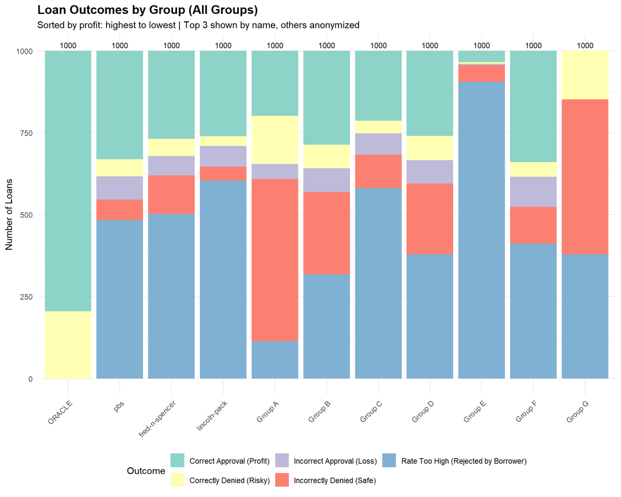

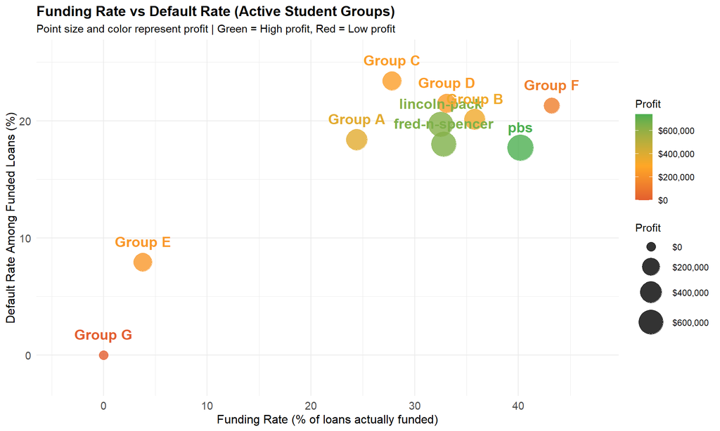

# Key Insights

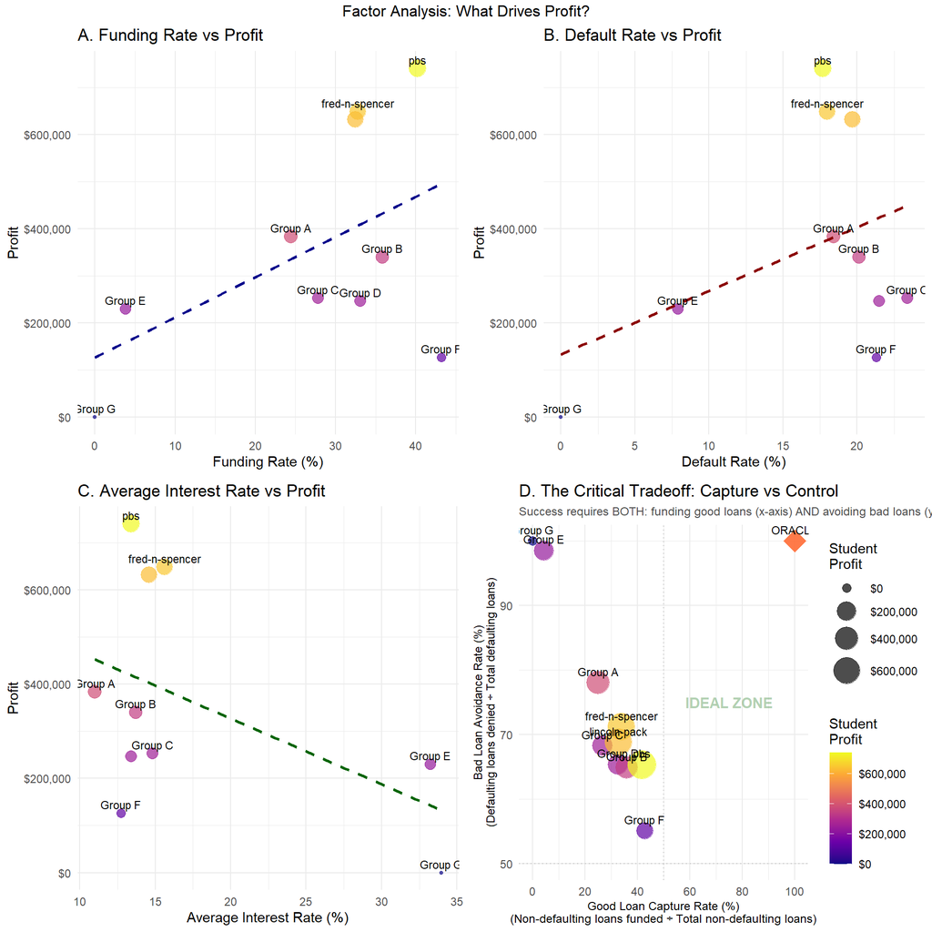

## What Separated Winners from Losers

To understand what drove success in this challenge, we compared the top-performing groups (top 25% by profit) against the lowest-performing groups (bottom 25%). The differences reveal clear patterns in what strategies worked and what didn’t.

Performance Comparison: Top 25% vs Bottom 25%

| Metric | Top 25% | Bottom 25% | Difference |
| --- | --- | --- | --- |
| Funding Rate | 35.2% | 15.7% | +19.5 pp |
| Default Rate | 18.5% | 9.7% | +8.7 pp |
| Interest Rate | 14.54% | 26.63% | -12.09 pp |
| Rejection Rate | 60.0% | 81.6% | -21.6 pp |

## Key Differentiators

The analysis reveals several critical factors that distinguished successful strategies:

**1. Strategic Loan Volume**

Successful groups funded 19.5 percentage points more loans than struggling groups. This demonstrates they weren’t overly conservative—they found the right balance between caution and opportunity. Higher volume, when combined with good risk management, directly translates to higher profits.

**2. Competitive Pricing Strategy**

Interestingly, top groups actually charged rates that were 12.09 percentage points lower than bottom performers. This suggests a volume-focused strategy where higher acceptance rates more than compensated for lower margins per loan. Success came from understanding that sometimes less is more.

**3. Precise Rate Calibration**

Top performers experienced 21.6 percentage points fewer loan rejections due to high interest rates. This indicates more accurate acceptance probability predictions—they avoided the costly mistake of offering rates that borrowers would reject, maximizing their funded loan volume.

## Summary: The Success Formula

### The Critical Insight

**Success required predicting BOTH default risk AND borrower acceptance.** Groups that focused on only one dimension underperformed. The winners understood this was a two-model problem from the start.